# Welcome to the WHO COVID-19 trend analysis repository

- Preamble
- Quick links
- Overall dynamics figures
- Contributions

[figure not shown]

# Preamble

## Forewords

Welcome to the repository implementing the COVID-19 surveillance pipelines developed by the WHO COVID-19 Analytics Team. For more information on the infrastructure, check the [dedicated website](https://asmodee-infrastructure-handbook.netlify.app/).

## General disclaimer

This repository contains work in progress. It implements an automated data pipeline for country-level surveillance of COVID-19 dynamics using publicly available data. Its content should not be used for publications without explicit agreement from the authors. The accuracy of the estimates provided in these analyses is contingent on data quality and availability. Results presented here do not represent the official view of the WHO, its staff or consultants. Caution must be taken when interpreting all data presented, and differences between information products published by WHO, national public health authorities, and other sources using different inclusion criteria and different data cut-off times are to be expected. While steps are taken to ensure accuracy and reliability, all data are subject to continuous verification and change. All counts are subject to variations in case detection, definitions, laboratory testing, vaccination strategy, and reporting strategies. See https://covid19.who.int/info/ for further background and other important considerations surrounding the source data. The designations employed and the presentation of these materials do not imply the expression of any opinion whatsoever on the part of WHO concerning the legal status of any country, territory or area or of its authorities, or concerning the delimitation of its frontiers or boundaries. We seek to provide results for countries in all WHO regions (see inclusion criteria below). For technical reasons (missing data, low incidence, model not successfully fitting to the data), results may not be available for some countries. Where this happens, the list of missing countries is indicated in the relevant sections.

## Content of this repository

This repository provides country-level analyses of COVID-19 dynamics characterised as summary figures, which outline:

- **x-axis**: the daily growth rate of reported cases
- **y-axis**: the current level of infections in the country (using 2 different metrics, see below)
- **color**: indications of increase in transmissibility from ASMODEE

The sections below provides details on these elements.

### Growth rates

The daily growth rate is estimated by fitting a Poisson GLM to reported cases over the last 3 weeks. Note that whilst it is able to fit most countries, this model may underestimate uncertainty. See [this issue](https://github.com/whocov/trend_analysis_public/issues/4) and [this one](https://github.com/whocov/trend_analysis_public/issues/5) for discussions on future improvements.

### Current levels of infection

Two metrics are used as proxy for the current levels of infection:

### Recent increases detected by ASMODEE

ASMODEE (**A**utomated **S**election of **M**odels and **D**etection of **O**utliers for **E**pid**E**mics) is a new method for detecting recent changes of trend in case incidence data. The initial publication (Jombart et al. 2021 Phil Trans B) describing the method is currently in press, and will be linked as soon as available.

## Inclusion criteria

Analyses are performed on all countries of WHO regions meeting the following criteria:

- reported at least 100 cases or tests over the last 7 weeks
- (*in analyses using peak incidence*) peak weekly incidence is strictly positive (i.e. at least on case was reported in the past)

## Getting in touch

- For bug reports, feature requests, or general feedback, please use github issues.
- You have questions, ideas, or comments you would like to share? Join our [discussion forum](https://github.com/whocov/trend_analysis_public/discussions).
- Contributions to this repository are welcome through [pull requests](https://github.com/whocov/trend_analysis_public/pulls).
- For further enquiries, send an email to Thibaut Jombart.

Note that for all matters of social interactions, this project is submitted to a code of conduct.

# Quick links

## Overall dynamics figures

- [AFRO](https://github.com/whocov/trend_analysis_public#afro-region)
- [EMRO](https://github.com/whocov/trend_analysis_public#emro-region)
- [EURO](https://github.com/whocov/trend_analysis_public#euro-region)
- [PAHO](https://github.com/whocov/trend_analysis_public#paho-region)
- [SEARO](https://github.com/whocov/trend_analysis_public#searo-region)
- [WPRO](https://github.com/whocov/trend_analysis_public#wpro-region)

## ASMODEE runs

This section contains links to *asmodee* results for each WHO region. Results are stored as *rds* files, each containing a `list` with the following items:

- `summary`: summary of the ASMODEE results
- `results`: outputs of ASMODEE
- `plot_overall_deaths`: *ggplot2* object of the overall dynamics plot using death per capita on the y-axis
- `plot_overall_peaks`: *ggplot2* object of the overall dynamics plot using incidence as percentage of historical peak on the y-axis

Links to the *rds* files:

- [AFRO](https://github.com/whocov/trend_analysis_public/raw/main/asmodee_outputs/rds/asmodee_outputs_AFRO_latest.rds)
- [EMRO](https://github.com/whocov/trend_analysis_public/raw/main/asmodee_outputs/rds/asmodee_outputs_EMRO_latest.rds)
- [EURO](https://github.com/whocov/trend_analysis_public/raw/main/asmodee_outputs/rds/asmodee_outputs_EURO_latest.rds)
- [PAHO](https://github.com/whocov/trend_analysis_public/raw/main/asmodee_outputs/rds/asmodee_outputs_PAHO_latest.rds)
- [SEARO](https://github.com/whocov/trend_analysis_public/raw/main/asmodee_outputs/rds/asmodee_outputs_SEARO_latest.rds)
- [WPRO](https://github.com/whocov/trend_analysis_public/raw/main/asmodee_outputs/rds/asmodee_outputs_WPRO_latest.rds)

# Overall dynamics figures

## AFRO region

[figure not shown]

Analyses were last updated **Monday 09 August 2021**.  
**Notes**  
The following countries reported < 100 cases/tests over the last 7 weeks and were not included in further analyses:  
Chad, Comoros, Saint Helena

### Infection levels as % of historical incidence peak

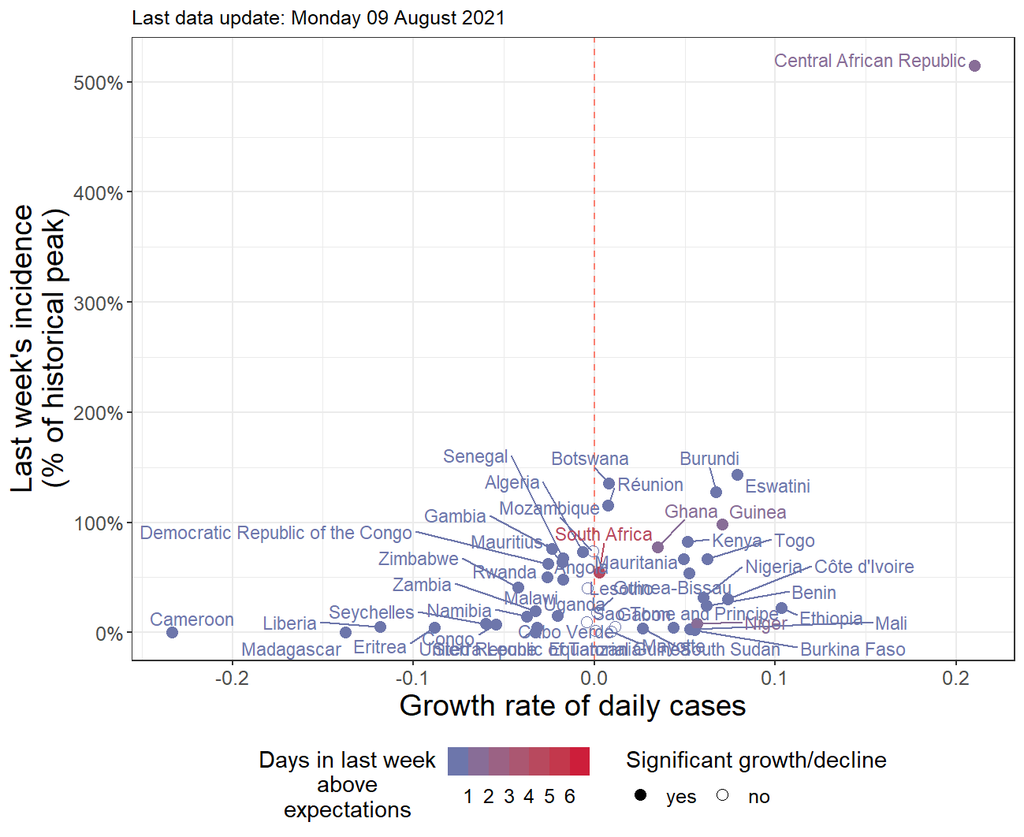

### Infection levels as weekly deaths per 1M inhabitants

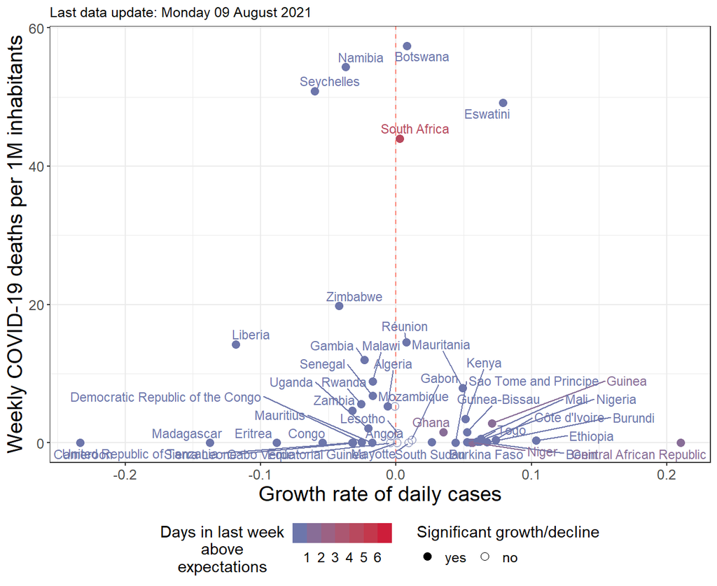

## EMRO region

[figure not shown]

Analyses were last updated **Monday 09 August 2021**.  
**Notes**  
The following countries reported < 100 cases/tests over the last 7 weeks and were not included in further analyses:  
Djibouti

### Infection levels as % of historical incidence peak

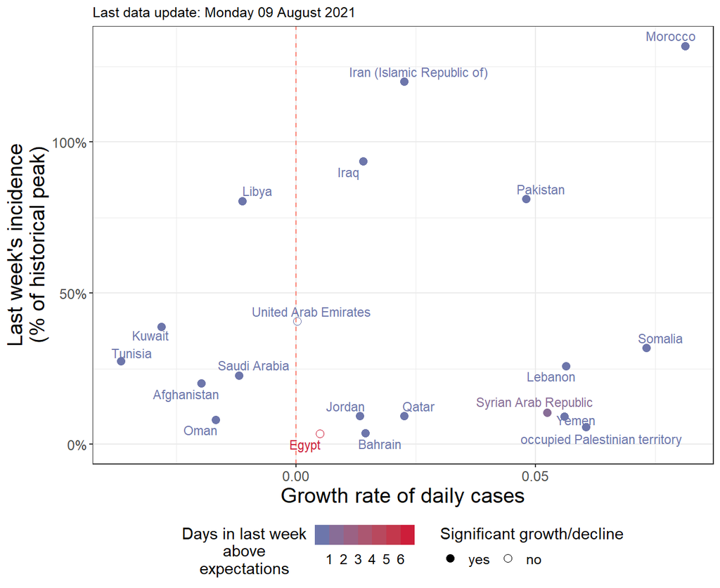

### Infection levels as weekly deaths per 1M inhabitants

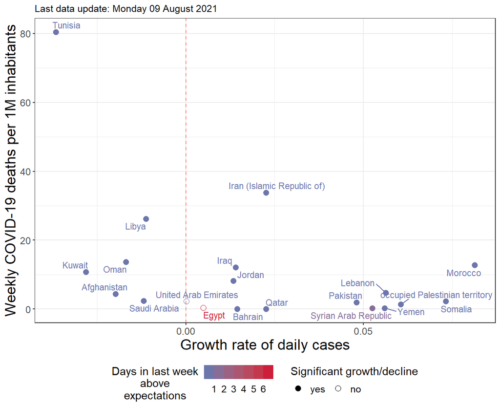

## EURO region

[figure not shown]

Analyses were last updated **Monday 09 August 2021**.  
**Notes**  
The following countries reported < 100 cases/tests over the last 7 weeks and were not included in further analyses:  
Holy See, San Marino

### Infection levels as % of historical incidence peak

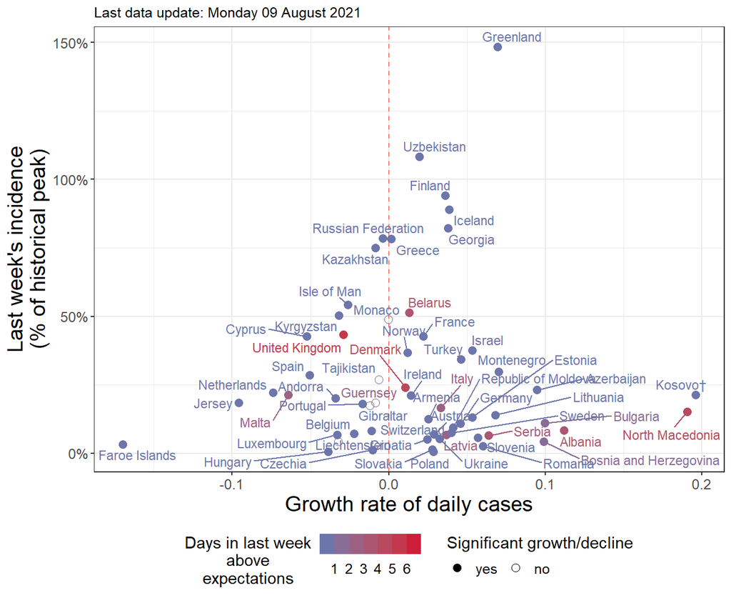

### Infection levels as weekly deaths per 1M inhabitants

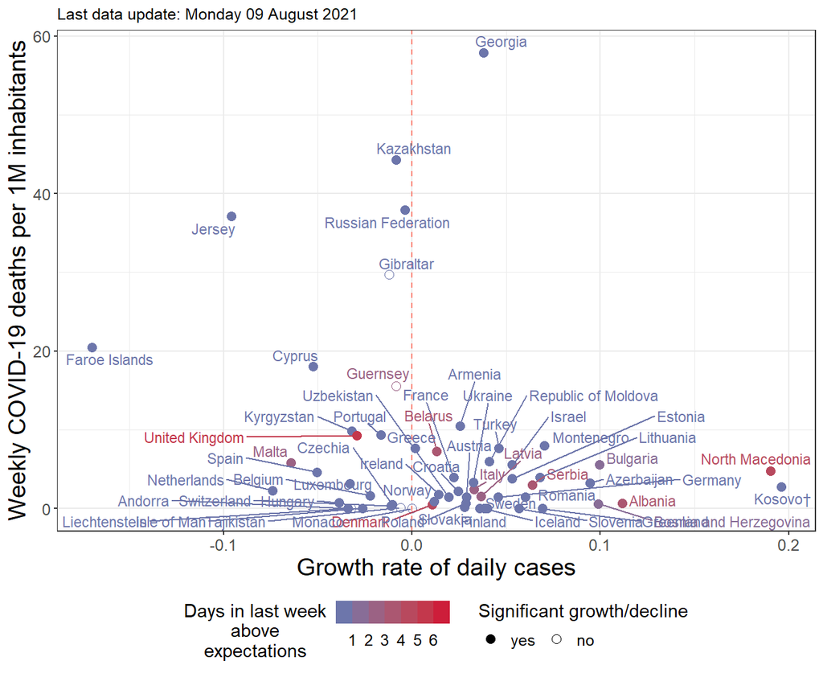

† All references to Kosovo should be understood to be in the context of the United Nations Security Council resolution 1244 (1999).

## PAHO region

[figure not shown]

Analyses were last updated **Monday 09 August 2021**.  
**Notes:** The following countries reported < 100 cases/tests over the last 7 weeks and were not included in further analyses:  
Anguilla, Antigua and Barbuda, Bonaire, Sint Eustatius and Saba, Cayman Islands, Dominica, Falkland Islands (Malvinas), Grenada, Montserrat, Saint Pierre and Miquelon, Turks and Caicos Islands

**Notes of geographic units**:

- a dispute exists between the Governments of Argentina and the United Kingdom of Great Britain and Northern Ireland concerning sovereignty over the Falkland Islands (Malvinas)
- data for Bonaire, Sint Eustatius and Saba have been disaggregated and displayed at the subnational level.

### Infection levels as % of historical incidence peak

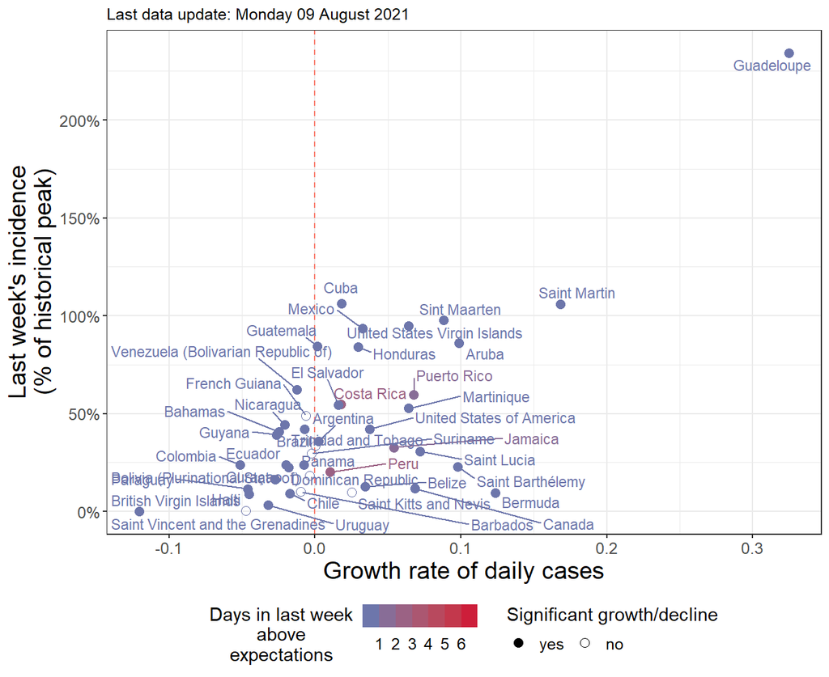

### Infection levels as weekly deaths per 1M inhabitants

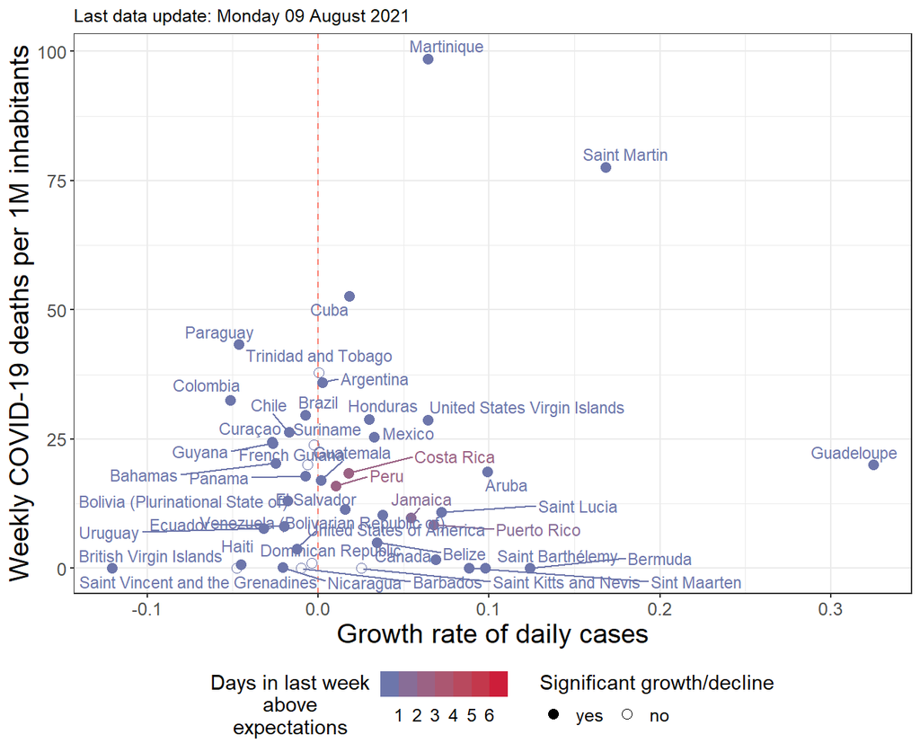

## SEARO region

Analyses were last updated **Monday 09 August 2021**.  
**Notes**  
The following countries reported < 100 cases/tests over the last 7 weeks and were not included in further analyses:  
Democratic People’s Republic of Korea

### Infection levels as % of historical incidence peak

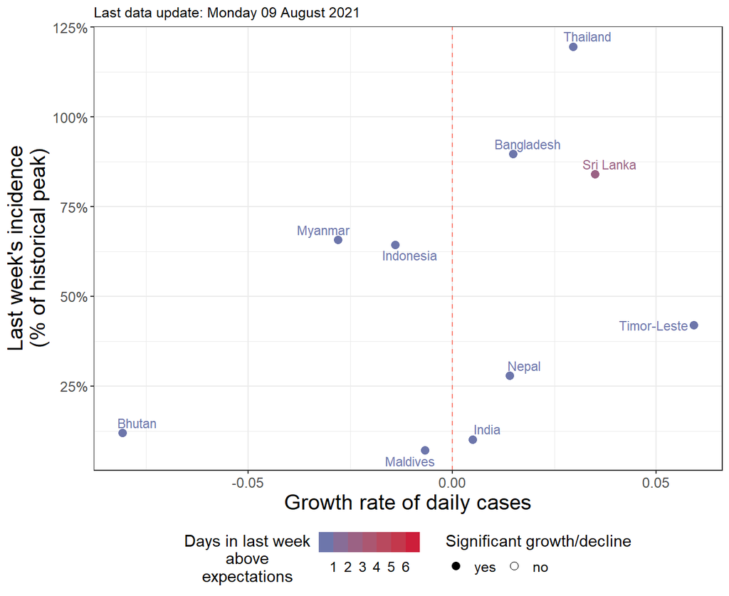

### Infection levels as weekly deaths per 1M inhabitants

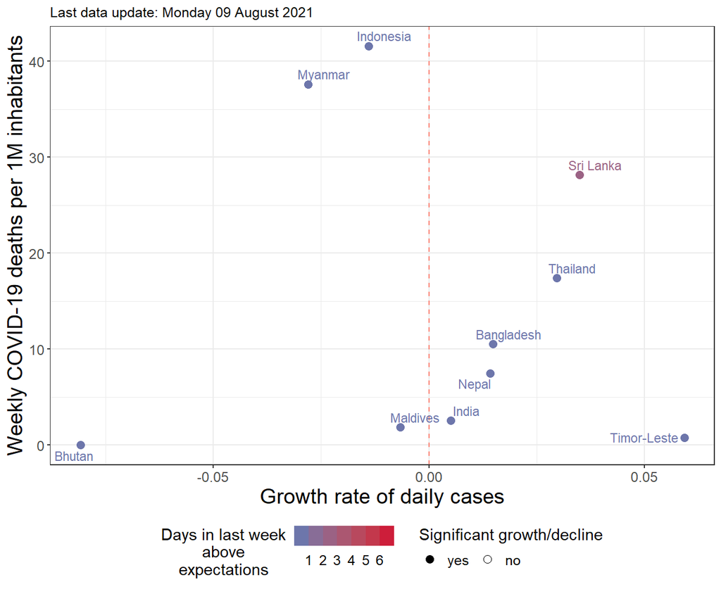

## WPRO region

[figure not shown]

Analyses were last updated **Monday 09 August 2021**.  
**Notes**  
The following countries reported < 100 cases/tests over the last 7 weeks and were not included in further analyses:  
American Samoa, Brunei Darussalam, Cook Islands, Kiribati, Marshall Islands, Micronesia (Federated States of), Nauru, New Caledonia, Niue, Palau, Pitcairn Islands, Samoa, Solomon Islands, Tokelau, Tonga, Tuvalu, Vanuatu, Wallis and Futuna  
Estimates of *r* could not be produced for the following countries:  
New Zealand

### Infection levels as % of historical incidence peak

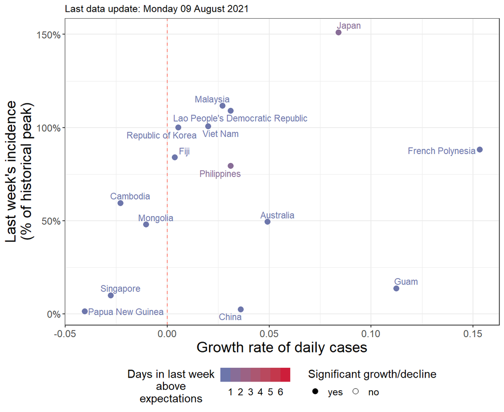

### Infection levels as weekly deaths per 1M inhabitants

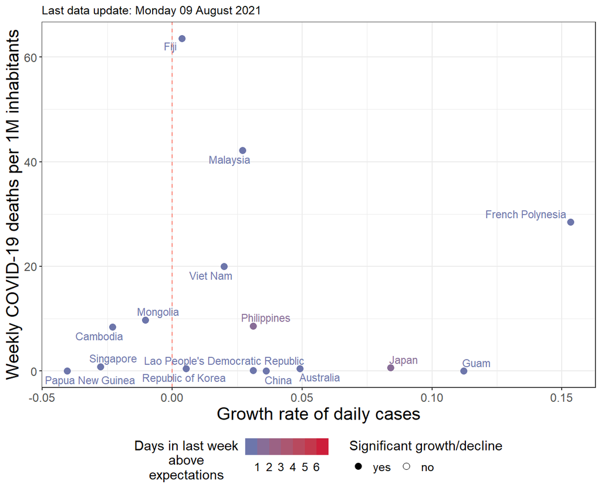

# Contributions

## Contributors

This pipeline benefits from the contributions of the WHO COVID-19 analytics team, with feedback and inputs from colleagues outside the team. Contributions are listed by alphabetic order:

Code, data and original design:

- Neale Batra
- Yuka Jinnai
- Thibaut Jombart
- Olivier le Polain
- Henry Laurenson-Schafer
- Katelijn Vandemaele

Contributed ideas and feedback:

- Brett Archer
- Raquel Medialdea Carrera
- Laura Guzman (original idea of *Tadpole* plots)
- Esther Hamblion
- Orlagh Ingeborg
- Zyleen Kassamali

## Sending feedback

Feedback is welcome via github issues. When filing a new issue:

- first check if a similar issue already exists
- specify whether this is a bug report or a feature request

## Contributing to this repository

Contributions to this repository are welcome through [pull requests](https://github.com/whocov/trend_analysis_public/pulls).

## Contact

For further enquiries, send an email to Thibaut Jombart.

### License

This repository is distributed under MIT license (see attached files).

### Code of Conduct

This project is submitted to a code of conduct.